# Big Data Capstone Design Team Project EDA

Joel Shin

2023-05-04

## EDA 세팅 및 데이터 로드

```r
set.seed(2020)
library(readxl)
library(tidyr)
library(MLmetrics)
library(purrr)
library(tidyverse)
library(plotly)
library(caret)
library(reshape2)
library(randomForest)
library(rpart)
library(ROCR)
library(C50)
library(xgboost)
library(readr)
library(foreign)

options(scipen = 1000)
setwd("C:/contest")

people <- read_excel("people.xlsx")
reservoir <- read_excel("reservoir.xlsx")
factory <- read_csv("factory.csv")
crops_rice <- read.dbf("crops_rice.dbf")
Sinnyeong_myeon_rain <- read_csv("weather/신녕면_1시간강수량_20220101_20221231.csv")
Chungtungmyeon_rain <- read_csv("weather/청통면_1시간강수량_20220101_20221231.csv")
Hwasanmyeon_rain <- read_csv("weather/화산면_1시간강수량_20220101_20221231.csv")
Sinnyeong_myeon_snow <- read_csv("weather/신녕면_1시간적설_20220101_20221231.csv")
Chungtungmyeon_snow <- read_csv("weather/청통면_1시간적설_20220101_20221231.csv")
Hwasanmyeon_snow <- read_csv("weather/화산면_1시간적설_20220101_20221231.csv")
Sinnyeong_myeon_humidity <- read_csv("weather/신녕면_습도_20220101_20221231.csv")
Chungtungmyeon_humidity <- read_csv("weather/청통면_습도_20220101_20221231.csv")
Hwasanmyeon_humidity <- read_csv("weather/화산면_습도_20220101_20221231.csv")
```

5월 4일 10주차 기준, 영천시 내 가뭄관련 데이터는 총 5개가 수집이 되었으며 세부 내용은 아래와 같음

- 인구 데이터 : 면읍동 기준 데이터 수집, 아쉽게도 리 단위까지의 인구 데이터는 수집하지 못함
- 저수지 데이터 : 영천시 내 존재하는 저수지 정보 확보, 저수량, 위치 등에 대한 정보 내포
- 농경 재배 데이터 : 영천시 논, 휴경지, 작물, 과수 재배 정보 확보, 현 EDA에서는 논 재배 정보를 활용하여 진행
- 공장 데이터 : 영천시 공장 위치 정보 데이터 확보
- 기상 데이터 : 2022년도 영천시 강우 관련 데이터 확보

추가 확보 예정 데이터 - 영천시 학교 정보 데이터 - 영천시 체육 시설 및 공원 위치 정보 데이터 + 그 밖에 물 활용이 많은 공공데이터 수집 시도 예정

## 영천시 인구 분석

```r
# 데이터 오버뷰
head(people)
```

```
## # A tibble: 6 × 11
##   `인구 및 세대현황` ...2  ...3  ...4  ...5  ...6  ...7  ...8  ...9  ...10 ...11
##   <chr>              <chr> <chr> <chr> <chr> <chr> <chr> <chr> <chr> <chr> <chr>
## 1 행정기관:          경상…  <NA> <NA>  <NA>   <NA> <NA>  <NA>  <NA>  <NA>  <NA>
## 2 작성기준:          2023…  <NA> <NA>  <NA>   <NA> 출력… <NA>  <NA>  <NA>  (단…
## 3 행정기관           <NA>  "인\… <NA>  <NA>  "구\… <NA>  <NA>  성비  세대… 세대…
## 4 <NA>               <NA>  "계"  남    여    "계"  남    여    <NA>  <NA>  <NA>
## 5 영천시             <NA>  "100… 51,3… 49,5… "100… 50.89 49.11 103.… 54,6… 1.85
## 6 금호읍             <NA>  "10,… 5,549 4,988 "10.… 5.50  4.94  111.… 6,222 1.69
```

```r
# 영화지구에 해당되는 지역들 추출 및 NA 변수 제거
object_people <- people[c(6:8),-2]
names(object_people) <- c("지역", "총인구수", "남인구수", "여인구수", "남녀구성비", "남구성비", "여구성비", "성비", "세대수", "세대당인구수")

# 필터링 이후 데이터 오버뷰
head(object_people)
```

```
## # A tibble: 3 × 10
##   지역   총인구수 남인구수 여인구수 남녀구성비 남구성비 여구성비 성비   세대수
##   <chr>  <chr>    <chr>    <chr>    <chr>      <chr>    <chr>    <chr>  <chr>
## 1 금호읍 10,537   5,549    4,988    10.44      5.50     4.94     111.25 6,222
## 2 청통면 3,988    2,092    1,896    3.95       2.07     1.88     110.34 2,365
## 3 신녕면 3,687    1,818    1,869    3.65       1.80     1.85     97.27  2,297
## # ℹ 1 more variable: 세대당인구수 <chr>
```

```r
# 적용 방안
# 다른 데이터와 병합을 진행할 때, 지역별로 총인구수, 남인구수, 여인구수, 성비, 세대수, 서대당인구수 변수를 활용하여 병합
object_people %>% select(지역, 총인구수, 남인구수, 여인구수, 성비, 세대수, 세대당인구수) -> object_people
convert_to_numeric <- function(x) {
  x <- gsub(",", "", x)
  return(as.numeric(x))
}

# 열 데이터 타입 전처리
str(object_people)
```

```
## tibble [3 × 7] (S3: tbl_df/tbl/data.frame)
##  $ 지역        : chr [1:3] "금호읍" "청통면" "신녕면"
##  $ 총인구수    : chr [1:3] "10,537" "3,988" "3,687"
##  $ 남인구수    : chr [1:3] "5,549" "2,092" "1,818"
##  $ 여인구수    : chr [1:3] "4,988" "1,896" "1,869"
##  $ 성비        : chr [1:3] "111.25" "110.34" "97.27"
##  $ 세대수      : chr [1:3] "6,222" "2,365" "2,297"
##  $ 세대당인구수: chr [1:3] "1.69" "1.69" "1.61"
```

```r
object_people$지역 -> region
object_people %>% select(-지역) %>% mutate_all(convert_to_numeric) -> object_people
object_people$지역 <- region
rm(region, convert_to_numeric)
object_people %>% select(지역, 총인구수, 남인구수, 여인구수, 성비, 세대수, 세대당인구수) -> object_people
```

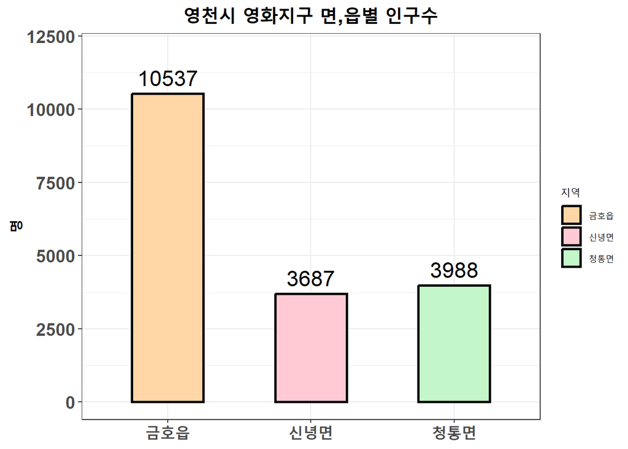

```r
# 영화지구 면,읍별 인구수 시각화화
pastel_colors <- c("#FFD6A5", "#FFCAD4", "#C3F6C8")
object_people %>%
  ggplot(aes(x = 지역, y = 총인구수, fill = 지역)) +
  geom_col(width = 0.5, color = "black", size = 1) +
  scale_fill_manual(values = pastel_colors) +
  theme_bw() +
  ylab("명") +
  xlab(NULL) +
  ggtitle("영천시 영화지구 면,읍별 인구수") +
  theme(plot.title = element_text(size = 17, face = "bold", hjust = 0.5),
        axis.title = element_text(size = 14, face = "bold"),
        axis.text = element_text(size = 14, face = "bold")) +
  geom_text(aes(label = paste0(총인구수)), vjust = -0.5, size = 6) +
  scale_y_continuous(limits = c(0, 12000))
```

금호면의 인구가 신녕면 및 청통면의 인구보다 높게 나타남

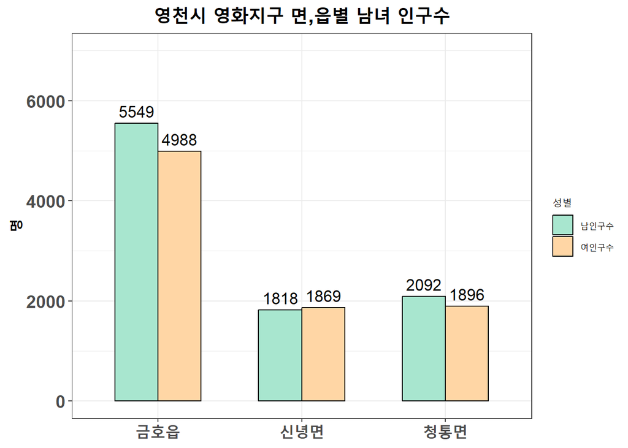

```r
# 영화지구 면,읍별 남녀인구수 시각화화
pastel_colors <- c("#A8E6CF", "#FFD6A5", "#D0F0C0")
object_people %>%
  gather(남인구수, 여인구수, key = "key", value = "value") %>%
  mutate(성별 = key) %>%
  ggplot(aes(지역,value, fill = 성별)) +
  geom_col(position = "dodge", width = 0.6, color = "black", size = 0.5) +
  scale_fill_manual(values = pastel_colors) +
  theme_bw() +
  ylab("명") +
  xlab(NULL) +
  ggtitle("영천시 영화지구 면,읍별 남녀 인구수") +
  theme(plot.title = element_text(size = 17, face = "bold", hjust = 0.5),
        axis.title = element_text(size = 14, face = "bold"),
        axis.text = element_text(size = 14, face = "bold")) +
  geom_text(aes(label = value, group = 성별),
            position = position_dodge(width = 0.6), vjust = -0.5, size = 4.5) +
  scale_y_continuous(limits = c(0, 7000))
```

인구 성비의 경우 금호읍과 청통면은 남성의 인구 비율이 높게 나타나며, 신녕면의 남성 인구 비율이 낮게 나타나는 것을 확인

```r
# 영화지구 인구 정보
object_people
```

```
## # A tibble: 3 × 7
##   지역   총인구수 남인구수 여인구수  성비 세대수 세대당인구수
##   <chr>     <dbl>    <dbl>    <dbl> <dbl>  <dbl>        <dbl>
## 1 금호읍    10537     5549     4988 111.    6222         1.69
## 2 청통면     3988     2092     1896 110.    2365         1.69
## 3 신녕면     3687     1818     1869  97.3   2297         1.61
```

```r
non_object_people <- people[c(5,9:21),-2]
names(non_object_people) <- c("지역", "총인구수", "남인구수", "여인구수", "남녀구성비", "남구성비", "여구성비", "성비", "세대수", "세대당인구수")
# 열 데이터 타입 전처리
non_object_people %>% select(지역, 총인구수, 남인구수, 여인구수, 성비, 세대수, 세대당인구수) -> non_object_people
convert_to_numeric <- function(x) {
  x <- gsub(",", "", x)
  return(as.numeric(x))
}
str(non_object_people)
```

```
## tibble [14 × 7] (S3: tbl_df/tbl/data.frame)
##  $ 지역        : chr [1:14] "영천시" "화산면" "화북면" "화남면" ...
##  $ 총인구수    : chr [1:14] "100,956" "3,117" "2,168" "3,219" ...
##  $ 남인구수    : chr [1:14] "51,379" "1,617" "1,071" "1,707" ...
##  $ 여인구수    : chr [1:14] "49,577" "1,500" "1,097" "1,512" ...
##  $ 성비        : chr [1:14] "103.63" "107.80" "97.63" "112.90" ...
##  $ 세대수      : chr [1:14] "54,684" "1,783" "1,341" "1,911" ...
##  $ 세대당인구수: chr [1:14] "1.85" "1.75" "1.62" "1.68" ...
```

```r
non_object_people$지역 -> region
non_object_people %>% select(-지역) %>% mutate_all(convert_to_numeric) -> non_object_people
non_object_people$지역 <- region
rm(region, convert_to_numeric)
non_object_people %>% select(지역, 총인구수, 남인구수, 여인구수, 성비, 세대수, 세대당인구수) -> non_object_people

non_object_people %>% summarise(type = "non_object", 평균인구수 = mean(총인구수), 평균성비 = mean(성비),
                            평균세대수 = mean(세대수), 평균세대당인구수 = mean(세대당인구수)) -> summary_non_object_people
object_people %>% summarise(type = "object",평균인구수 = mean(총인구수), 평균성비 = mean(성비),
                                평균세대수 = mean(세대수), 평균세대당인구수 = mean(세대당인구수)) -> summary_object_people
rbind(summary_non_object_people, summary_object_people)
```

```
## # A tibble: 2 × 5
##   type       평균인구수 평균성비 평균세대수 평균세대당인구수
##   <chr>           <dbl>    <dbl>      <dbl>            <dbl>
## 1 non_object     13121.     106.      7035.             1.77
## 2 object          6071.     106.      3628              1.66
```

단순 인구 정보많으로 식별되는 인사이트는 없었으나, 농경지 비율에 따라 성비의 차이가 존재할 수도 있을 것이라 여겨짐. 통상적인 도메인으로 인구수는 물 사용량에 비례할 수 있다는 것을 식별. 인구 관련 도메인 정보를 확보하기 위해 추가적인 도메인 리서치가 요구됨.

## 영천시 저수지 분석

```r
head(reservoir)
```

```
## # A tibble: 6 × 10
##   저수지명 `한발빈도(년)` 유역면적 유효저수량  댐형식 `관개면적(ha)` ...7  ...8
##   <chr>             <dbl> <chr>    <chr>       <chr>  <chr>          <chr> <chr>
## 1 <NA>                 NA (ha)     (천m³)      <NA>   계             순관… 관배…
## 2 가곡                 10 34       39.4        필댐(… 3              3     <NA>
## 3 가꼴                  3 4        1.2         필댐(… 6              6     <NA>
## 4 가는곡2               3 23       5.09999999… 필댐(… 5.3            5.3   <NA>
## 5 가는골               10 6        1           필댐(… 0              <NA>  <NA>
## 6 가는골               10 16       2.4         필댐(… 0              <NA>  <NA>
## # ℹ 2 more variables: ...9 <chr>, 소재지 <chr>
```

```r
reservoir <- reservoir[-1,]
names(reservoir) <- c("저수지명", "한발빈도", "유역면적_ha", "유효저수량_km3", "댐형식",
                      "관개면적_ha", "순관개면적", "관배수면적", "구역외급수면적", "소재지")

# NA 변수 제거
reservoir <- reservoir[,-c(8,9)]

# NA 변수 제거
reservoir$유역면적_ha <- as.numeric(reservoir$유역면적_ha)
reservoir$유효저수량_km3 <- as.numeric(reservoir$유효저수량_km3)
reservoir$관개면적_ha <- as.numeric(reservoir$관개면적_ha)
reservoir$순관개면적 <- as.numeric(reservoir$순관개면적)
reservoir$댐형식 <- as.factor(reservoir$댐형식)

# 영화지구 이외에 해당되는 지역 필터링
reservoir %>% filter(str_detect(소재지,"가천리") == FALSE &
                       str_detect(소재지,"화성리") == FALSE &
                       str_detect(소재지,"신덕리") == FALSE &
                       str_detect(소재지,"대안리") == FALSE &
                       str_detect(소재지,"용평리") == FALSE &
                       str_detect(소재지,"덕암리") == FALSE &
                       str_detect(소재지,"용천리") == FALSE) -> non_object_reservoir

# 영화지구에 해당되는 지역 필터링
reservoir %>% filter(str_detect(소재지,"가천리") == TRUE |
                       str_detect(소재지,"화성리") == TRUE |
                       str_detect(소재지,"신덕리") == TRUE |
                       str_detect(소재지,"대안리") == TRUE |
                       str_detect(소재지,"용평리") == TRUE |
                       str_detect(소재지,"덕암리") == TRUE |
                       str_detect(소재지,"용천리") == TRUE) -> object_reservoir

# 지역명 내용 추가(추후 병합에 활용)
object_reservoir$지역 <- if_else(str_detect(object_reservoir$소재지, "신녕면") == TRUE, "신녕면",
                        if_else(str_detect(object_reservoir$소재지, "화산면") == TRUE, "화산면", "청통면"))

non_object_reservoir %>%
  summarise(type = "non_object", 한발빈도 = mean(한발빈도, na.rm = TRUE), 유역면적_ha = mean(유역면적_ha, na.rm = TRUE),
            유효저수량_km3 = mean(유효저수량_km3, na.rm = TRUE), 관개면적_ha = mean(관개면적_ha, na.rm = TRUE),
            순관개면적 = mean(순관개면적, na.rm = TRUE)) -> summary_non_object_reservoir
object_reservoir %>%
  summarise(type = "object", 한발빈도 = mean(한발빈도, na.rm = TRUE), 유역면적_ha = mean(유역면적_ha, na.rm = TRUE),
            유효저수량_km3 = mean(유효저수량_km3, na.rm = TRUE), 관개면적_ha = mean(관개면적_ha, na.rm = TRUE),
            순관개면적 = mean(순관개면적, na.rm = TRUE)) -> summary_object_reservoir

rbind(summary_non_object_reservoir, summary_object_reservoir) -> compare_dam

compare_dam
```

```
## # A tibble: 2 × 6
##   type       한발빈도 유역면적_ha 유효저수량_km3 관개면적_ha 순관개면적
##   <chr>         <dbl>       <dbl>          <dbl>       <dbl>      <dbl>
## 1 non_object     5.25        48.9           37.4        5.94       7.67
## 2 object         5.5         48.6           32.9        7.08       7.93
```

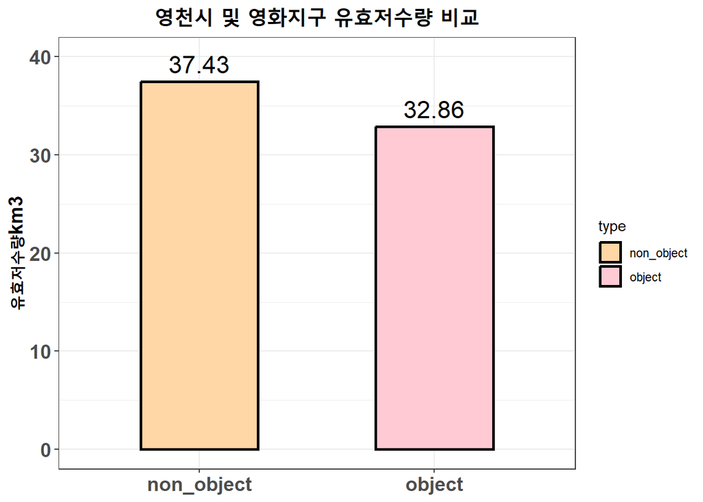

```r
# 영화지구의 저수지들이 다른 영천시 내 저수지들보다 유효저수량이 상대적으로 부족
pastel_colors <- c("#FFD6A5", "#FFCAD4")
compare_dam %>%
  ggplot(aes(type, 유효저수량_km3, fill = type)) +
  scale_fill_manual(values = pastel_colors) +
  geom_col(width = 0.5, color = "black", size = 1) +
  theme_bw() +
  ylab("유효저수량km3") +
  xlab(NULL) +
  ggtitle("영천시 및 영화지구 유효저수량 비교") +
  theme(plot.title = element_text(size = 17, face = "bold", hjust = 0.5),
        axis.title = element_text(size = 14, face = "bold"),
        axis.text = element_text(size = 14, face = "bold")) +
  geom_text(aes(label = paste0(round(유효저수량_km3,2))), vjust = -0.5, size = 6) +
  scale_y_continuous(limits = c(0, 40))
```

영화지구를 제외한 영천시와 영화지구의 저수지 평균 수치를 비교해본 결과, 유효저수량은 적은것에 비해 관개면적량이 보다 높은 것을 확인함으로써, 영화지구는 주변 인프라 및 환경 대비 많은 물을 사용중임을 확인

한발 : 공사에서는 “한발빈도”라는 말을 사용하고 있는데 예를 들어 어떤 저수지의 설계 시 적용된 한발 빈도가 10년이라면 10년에한 번 올 정도의 가뭄이 발생하더라도 주변 지역에 물을 충분히 공급할 수 있을 정도로 저수지를 설계했다는 뜻

순관개면적 : 순관개면적은 토지의 총 면적에서 길, 건물, 물이나 계곡 등 농작물을 재배할 수 없는 부분을 제외한 부분. 이 면적은농작물의 생산량을 추정하거나 농업 계획을 세울 때 중요한 지표로 사용됨